# Probability and stochasticity

PCB 6455 / BSC 4933: Biometry | Lecture 11

Dr. Brian Maitner

## Today’s agenda

1. Variability
2. Probability theory
3. Probability distributions
4. Working with distributions in R

## The story so far

**Lectures 9 and 10:** deterministic functions, the “signal” in a model.

**Today:** the “noise”: variability, and the probability rules that describe it.

**Next:** the distributions we use to model that noise.

# Variability

## Variability

**Increasing recognition of importance biologically** (e.g., intraspecific variation).

**Important component of statistical models** (“signal” vs “noise”).

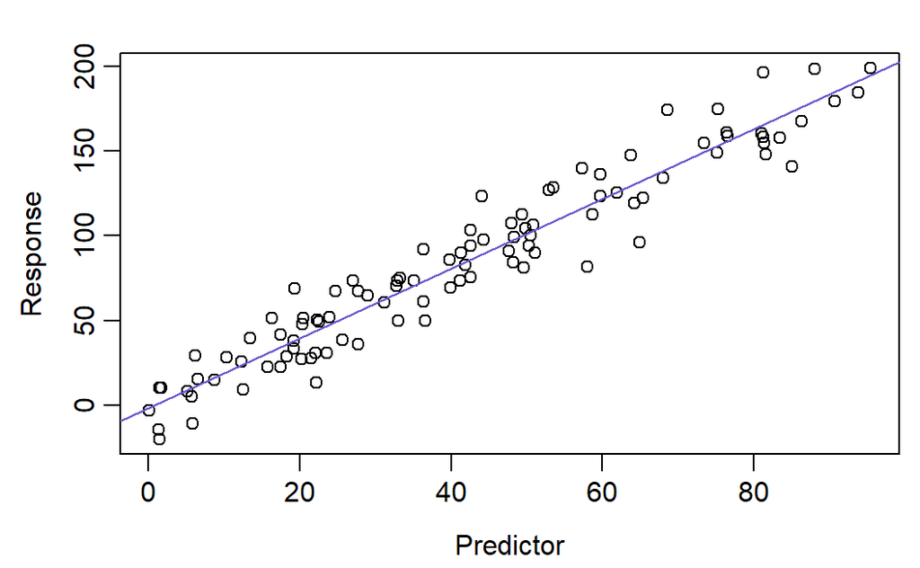

## Variability

Different sources of variability:

| Source | What it is | For example |
| --- | --- | --- |
| **Unmeasured variables** | unrecorded drivers, e.g. weather (environmental stochasticity) | a drought year lowers seedling survival, but rainfall isn’t in the data |
| **Measurement error** | the recorded value isn’t the true one | two people measure the same wing and get different lengths |
| **Inherent uncertainty** | random even if we knew everything | which allele a heterozygous parent passes on |
| **Demographic stochasticity** | chance in who survives or breeds; biggest in small populations | 50% survival of 3 animals: 0, 1, 2 or 3 survive, never 1.5 |
| **Nonlinear dynamics** | feedbacks that can damp or amplify variation | density dependence damps it; chaotic dynamics amplify tiny differences in starting numbers |

## Variability

Different ways of handling variability:

**Try to explain it** vs. **treat it as error.**

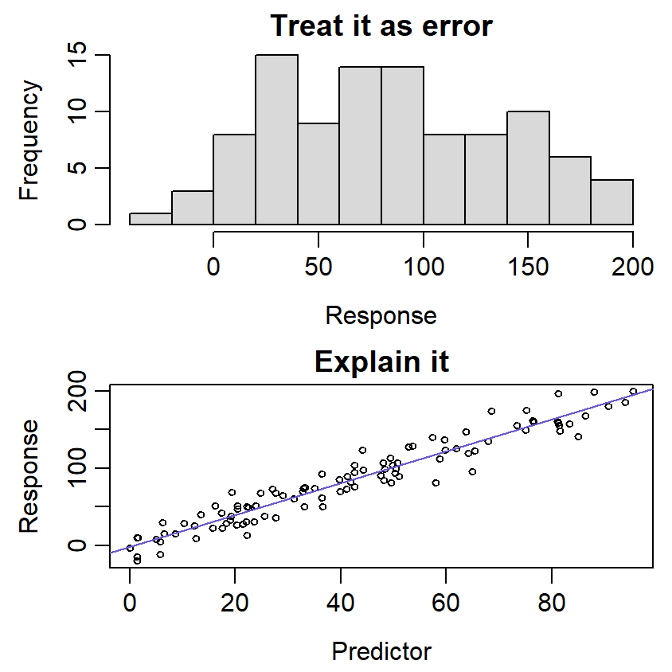

# Probability theory

## Probability theory refresher

**Probabilities sum to 1.**

## Probability theory refresher

**For mutually exclusive events:**

**P(A or B) = P(A) + P(B)**

**Dead or alive**

P(Dead) + P(Alive) = 1

If P(Dead) = 0.4,

then P(Alive) = 0.6

**Susceptible, infected, recovered**

P(S) + P(I) + P(R) = 1

If P(S) = 0.1 and P(R) = 0.2,

then P(S or R) = 0.3,

and P(I) = 1 − 0.3 = 0.7

## Probability theory refresher

**For non-mutually exclusive events, we have to account for double counting:**

**P(A or B) = P(A) + P(B) − P(A and B)**

P(Blue or Male)

= P(Blue) + P(Male) − P(Blue and Male)

= 0.50 + 0.35 − 0.20 = 0.65

The subtraction corrects for double counts.

|  | Male | Female |
| --- | --- | --- |
| **Blue** | 20 | 30 |
| **Green** | 15 | 35 |

## Can you just add them?

**P(A or B) = P(A) + P(B) only when A and B cannot both happen.**

**Which of these pairs can both happen at once?**

1. A frog is infected / the frog is uninfected
2. A bird is male / the bird is blue
3. A site is a pond / the site is a stream
4. A tree flowered this year / the tree is more than 20 cm across

**Check:** 2 and 4 can both happen, so you can’t just add them. 1 and 3 can’t, so you can.

## Probability theory refresher

**Conditional probability: the probability of something, given something else.**

**P(A | B) = P(A and B) / P(B)**

P(Male | Blue) = P(Blue male) / P(Blue)

0.40 = 0.20 / 0.50

|  | Male | Female |
| --- | --- | --- |
| **Blue** | 20 | 30 |
| **Green** | 15 | 35 |

Look only at the cases where B happened, and ask how often A happened among them.

## Probability theory refresher

**Independent variables: P(A and B) = P(A) × P(B)**

If sex and color were independent, we’d expect:

P(Blue male) = P(Blue) × P(Male)

0.175 = 0.5 × 0.35

0.20 ≠ 0.175: measurement error? dependence?

|  | Male | Female |
| --- | --- | --- |
| **Blue** | 20 | 30 |
| **Green** | 15 | 35 |

Independent means knowing one tells you nothing about the other.

## Practice: frogs and a fungus

**100 frogs, each scored for habitat and for infection with *Bd*.**

**Working in groups, figure out:**

1. P(infected)
2. P(infected and pond)
3. P(infected, given pond)
4. P(infected, given stream)
5. P(infected or pond)

|  | Pond | Stream | Total |
| --- | --- | --- | --- |
| **Infected** | 30 | 12 | 42 |
| **Uninfected** | 20 | 38 | 58 |
| **Total** | 50 | 50 | 100 |

## Answers

1. P(infected) = 42/100 = 0.42
2. P(infected and pond) = 30/100 = 0.30
3. P(infected | pond) = 0.30 / 0.50 = 0.60
4. P(infected | stream) = 0.12 / 0.50 = 0.24
5. P(infected or pond) = 0.42 + 0.50 − 0.30 = 0.62

Pond frogs are infected at 60%, stream frogs at 24%.

## P(A | B) is not P(B | A)

**P(A | B) = P(A and B) / P(B)**

P(infected | pond) = 0.30 / 0.50 = 0.60

P(pond | infected) = 0.30 / 0.42 = 0.71

Same numerator. Different denominator. Different question.

P(spots | measles) is nearly 1.

P(measles | spots) is nearly 0.

## Your turn: does habitat matter?

If infection and habitat were independent:

P(infected and pond) = P(infected) × P(pond)

1. Work out what that gives, and compare it to what we counted.
2. How many of the 100 frogs would be infected pond frogs?

|  | Pond | Stream | Total |
| --- | --- | --- | --- |
| **Infected** | 30 | 12 | 42 |
| **Uninfected** | 20 | 38 | 58 |
| **Total** | 50 | 50 | 100 |

## Answer: not independent

Expected if independent: 0.42 × 0.50 = 0.21, so 21 frogs.

Actually counted: 30 frogs.

More infected pond frogs than independence predicts. Habitat and infection are associated.

Knowing the habitat changes the probability.

**That is what a model is: P(outcome | what you know).**

## Questions so far?

# Probability distributions

## What to know about probability distributions

**Two classes:** discrete vs continuous.

**Discrete:** integers. E.g., individuals, number of events.

**Continuous:** any real number (or a subset, e.g. positives). E.g., body sizes, speeds, etc.

For continuous variables, P(any exact number) = 0, so we focus on P(some number or more extreme), e.g. P(x ≥ 4).

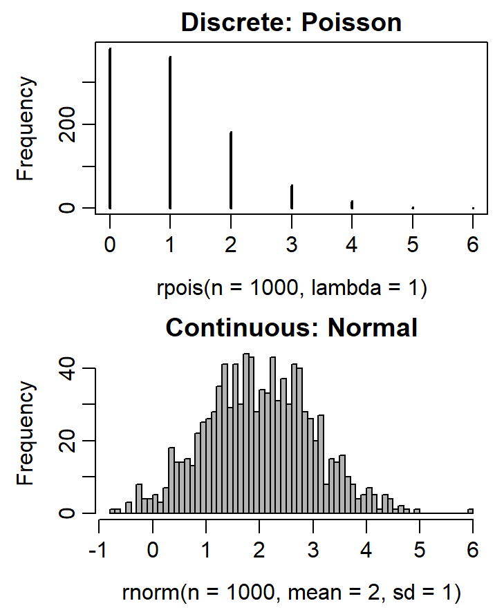

## Continuous or discrete?

| Organisms | Environment | Evolution |
| --- | --- | --- |
| Body mass | Temperature | Base pair substitutions |
| Age | Elevation | Evolutionary rate |
| Leaf area | Depth | Species per taxon |
| Population size | Hurricane severity |  |
| Population density |  |  |
| Species richness |  |  |
| Functional diversity |  |  |
| Individuals per transect |  |  |
| Mean body mass |  |  |

**Check:** counts are discrete (population size, species richness, individuals per transect, substitutions, species per taxon); the rest are continuous. Age and hurricane severity depend on how you record them.

## What to know about probability distributions

**Central tendencies: mean**

“Average”

Expected value (denoted *E*[*x*])

Also denoted $\bar{x}$

Use function `mean()`

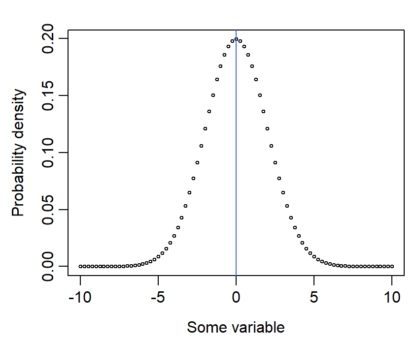

## What to know about probability distributions

**Central tendencies: median**

More robust than the mean: less sensitive to outliers and skew.

Use function `median()`

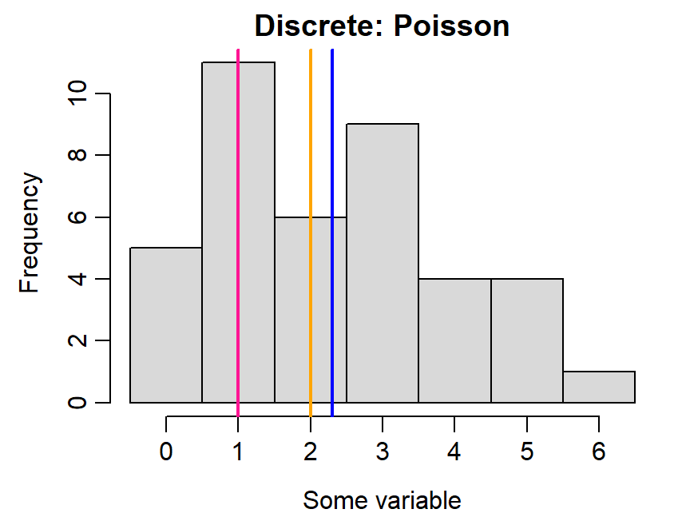

Blue = mean Orange = median Pink = mode

## What to know about probability distributions

**Central tendencies: mode**

Most likely or most common value.

No built-in function: the DescTools package has `Mode()`.

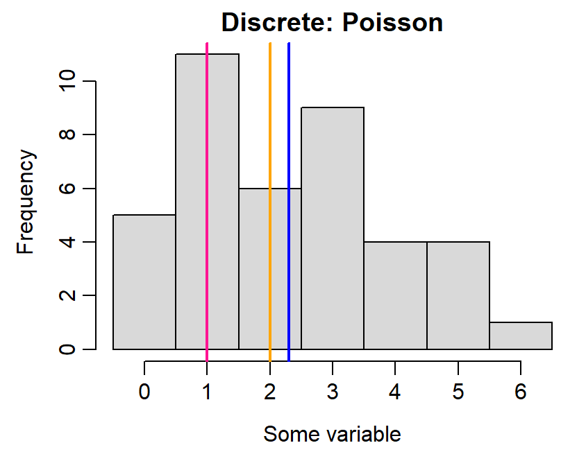

Blue = mean Orange = median Pink = mode

## What to know about probability distributions

**Spread: variance and standard deviation**

|  | Variance | SD |
| --- | --- | --- |
| Definition | SD² | √variance |
| Additive? | yes | no |
| Units | mean squared | same as the mean |
| Function | `var()` | `sd()` |

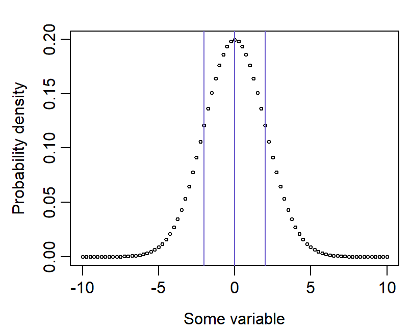

Blue lines: mean ± SD

# Working with distributions in R

## Activities

Load data and calculate the mean, variance, standard deviation, median, mode, etc.

We’ll use data on GitHub.

## Working with probability distributions

Load the AVONET data. **To get the link:** right click on “Raw”, copy the URL.

[figure not shown]

## Working with probability distributions

Load the AVONET data:

```r
avonet <- read.csv("https://github.com/bmaitner/biometry_course/raw/refs/heads/main/data/Avonet/AVONET1_BirdLife.csv")
```

Or, shorter, the same data:

```r
library(readr)
avonet <- read_rds("https://tinyurl.com/avonetbirddata")
```

## Working with probability distributions

Using the AVONET data:

1. Generate a histogram of Hand-Wing Index (high HWI = long-distance flyer), with `hist()`. The column is called `Hand.Wing.Index`.
2. Calculate the mean and median Hand-Wing Index: `mean()` and `median()`.
3. Generate a histogram of body mass. Also try a histogram of the log of body mass (use `log10()` or `log()`).
4. Calculate the mean and median body mass. How similar are they?
5. (optional) Try calculating the mode of body mass: `Mode()` in the DescTools package.

**Check:** HWI mean 25.4, median 21. Mass mean 267.1 g, median 35.5 g: not similar at all.

## Working with probability distributions

Using the AVONET data:

1. Calculate the variance and standard deviation of Mass: `var()` and `sd()`.
2. Check that variance equals SD². Use `==` to test whether things are equal. R uses `^` for powers, so `x^2` means x². For square roots, use either `sqrt()` or `x^0.5`.
3. Calculate the mean and variance of Range.Size.

Range.Size has missing values. What do `mean()` and `var()` give you? Fix it with `na.rm = TRUE`.

**Check:** SD 1,883 g. The `==` test may say TRUE or FALSE, depending on your computer (next slide). Range.Size gives NA until you add `na.rm = TRUE`: 57 species have no range size.

## Why did `==` say FALSE?

```r
0.1 + 0.2 == 0.3
print(0.1 + 0.2, digits = 20)
```

**Check:** FALSE, and 0.30000000000000004441.

The fix: compare with a tolerance.

```r
all.equal(var(avonet$Mass), sd(avonet$Mass)^2)
```

**Never use `==` on numbers with decimals. Use `all.equal()`.** `==` is fine for whole numbers and for text.

# Wrapping up

## Which tool, when

| You want | Use |
| --- | --- |
| P(A or B), when both can’t happen | P(A) + P(B) |
| P(A or B), when both can happen | P(A) + P(B) − P(A and B) |
| P(A given B) | P(A and B) / P(B): only count within B |
| to check independence | compare P(A and B) with P(A) × P(B) |
| the center of skewed data | `median()`, not just `mean()` |
| the spread | `var()` for the math, `sd()` for reporting |
| summaries with missing values | `na.rm = TRUE` |
| to compare decimals | `all.equal()`, not `==` |

## Remainder of class

Load in your focal data, and use today’s functions to better understand your key variables:

```r
# your focal dataset from Assignment 1
my_data <- read.csv("your_file.csv")

hist(my_data$your_variable)
hist(log10(my_data$your_variable))    # if the first one is skewed

mean(my_data$your_variable, na.rm = TRUE)
median(my_data$your_variable, na.rm = TRUE)
```

**Before next class:** skim 4.5 and 4.6, the bestiary of distributions.